# Analiza lotów w USA w latach 2001-2007

# Odwołane loty

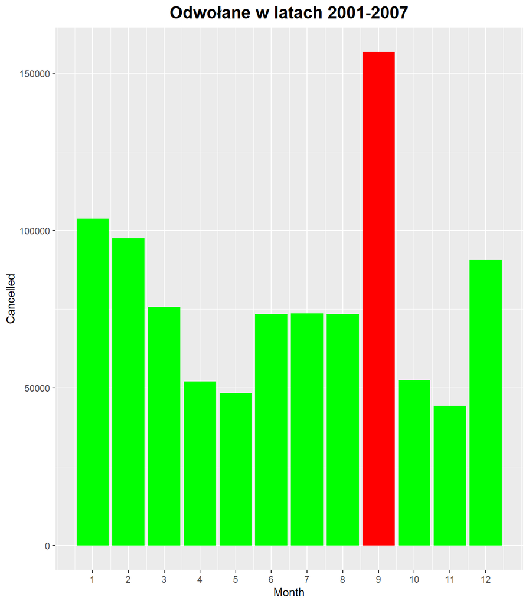

| Year | Cancelled | Cancelled_percent |
| --- | --- | --- |
| 2001 | 231198 | 3.87 |
| 2002 | 65143 | 1.24 |
| 2003 | 101469 | 1.56 |
| 2004 | 127757 | 1.79 |
| 2005 | 133730 | 1.87 |
| 2006 | 121934 | 1.71 |
| 2007 | 160748 | 2.16 |

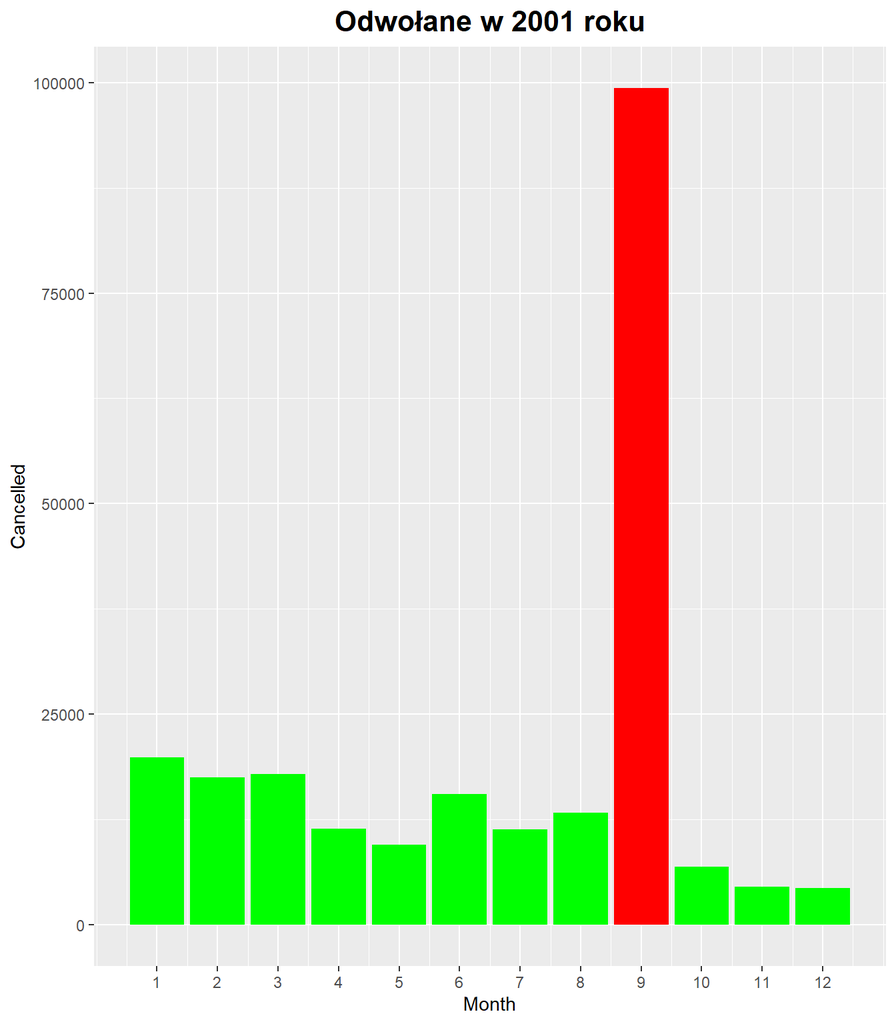

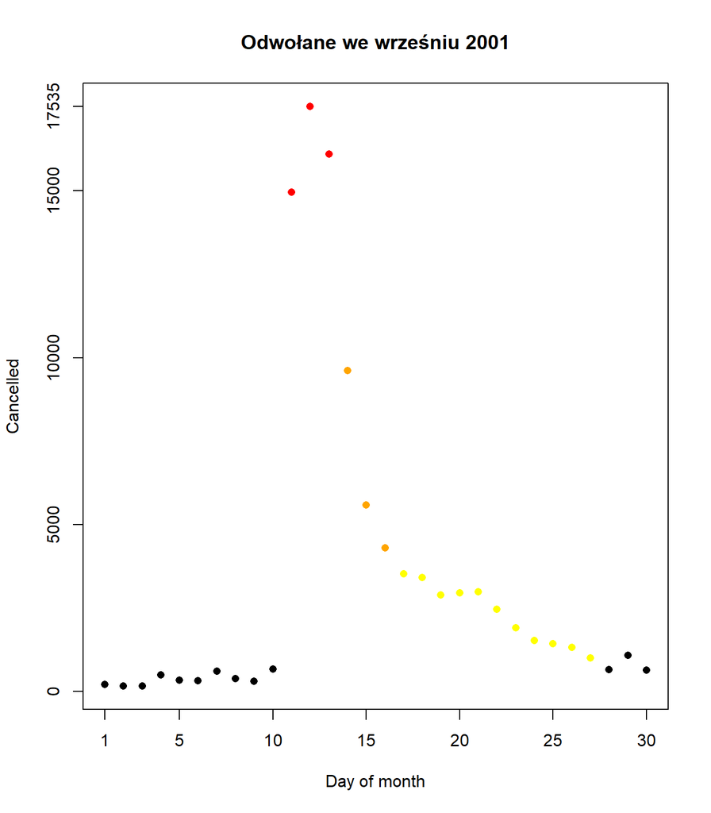

## Odwołania względem dnia tygodnia (w latach 2001-2007)

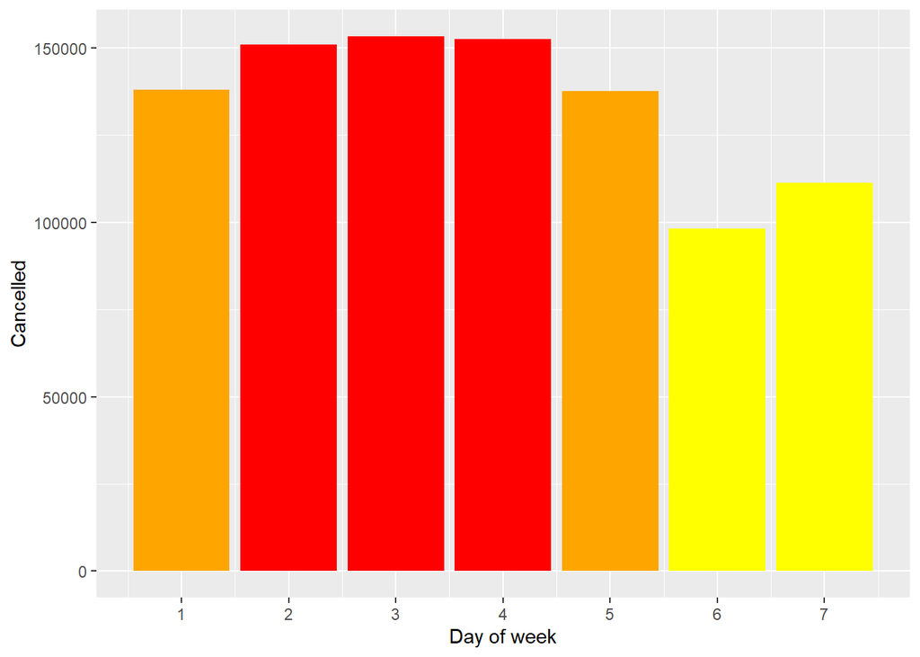

| DayOfWeek | Cancelled | Number | Cancelled_percent |
| --- | --- | --- | --- |
| 1 | 137973 | 6868782 | 2.01 |
| 2 | 151014 | 6779060 | 2.23 |
| 3 | 153304 | 6815210 | 2.25 |
| 4 | 152562 | 6850879 | 2.23 |
| 5 | 137597 | 6867742 | 2.00 |
| 6 | 98178 | 5914381 | 1.66 |
| 7 | 111351 | 6496628 | 1.71 |

## Odwołania a lotniska (w latach 2001-2007)

Loniska z największą liczbą odwołanych lotów:

| airport | Cancelled |
| --- | --- |
| Chicago O’Hare International | 83838 |
| William B Hartsfield-Atlanta Intl | 51607 |
| Dallas-Fort Worth International | 46057 |
| LaGuardia | 36206 |
| Gen Edw L Logan Intl | 31678 |
| Newark Intl | 31285 |

Lotniska z procentowo największą liczbą odwołanych lotów:

| airport | Number | Cancelled | Cancelled_percent |
| --- | --- | --- | --- |
| Unalaska | 2090 | 445 | 21.29 |
| Worcester Regional | 1281 | 178 | 13.90 |
| Nantucket Memorial | 1211 | 120 | 9.91 |
| Aspen-Pitkin Co/Sardy | 9038 | 850 | 9.40 |
| Kodiak | 4863 | 365 | 7.51 |
| Visalia Municipal | 1993 | 149 | 7.48 |

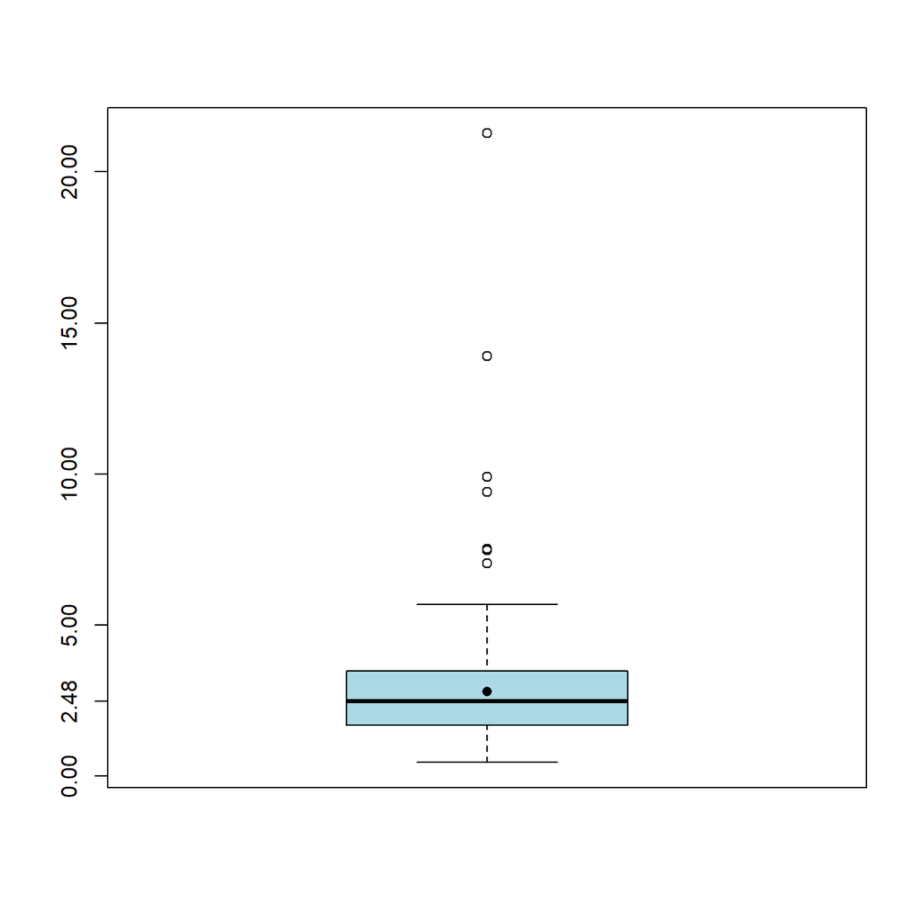

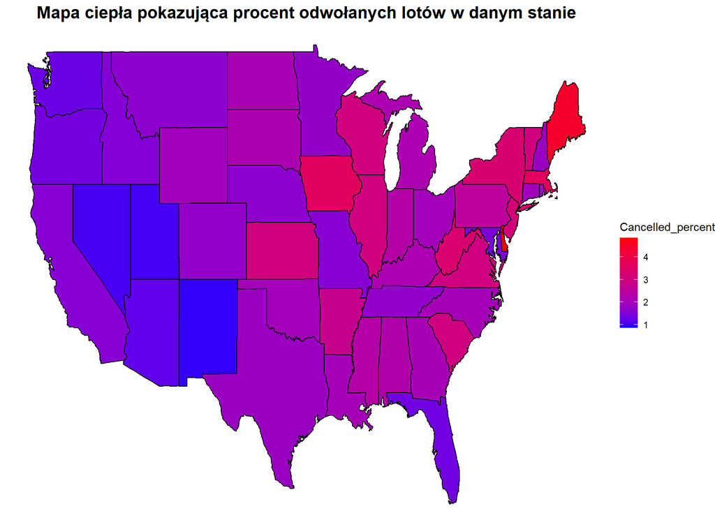

Stany z procentowo największą liczbą odwołanych lotów:

| state | Number | Cancelled | Cancelled_percent |
| --- | --- | --- | --- |
| DE | 765 | 37 | 4.84 |
| ME | 92946 | 4091 | 4.40 |
| MA | 880500 | 31976 | 3.63 |
| IA | 141012 | 5089 | 3.61 |
| WV | 29921 | 987 | 3.30 |
| NY | 2085076 | 67847 | 3.25 |

## Przyczyny odwołań w latach 2004-2007

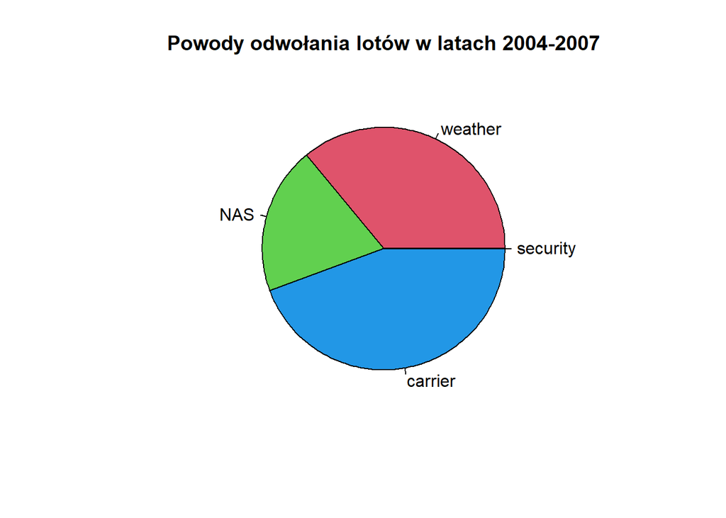

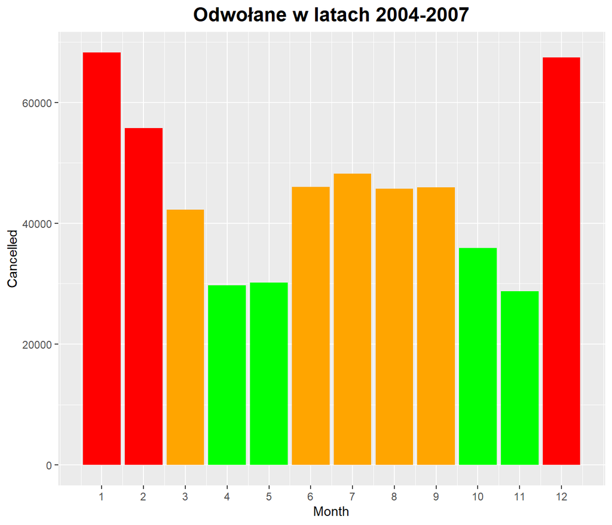

Odwołane loty w latach 2004-2007 w poszczególnych miesiącach:

| Month | Number | Cancelled | Cancelled_percent |
| --- | --- | --- | --- |
| 1 | 2381757 | 68259 | 2.87 |
| 2 | 2196059 | 55744 | 2.54 |
| 3 | 2463378 | 42235 | 1.71 |
| 4 | 2377461 | 29759 | 1.25 |
| 5 | 2443787 | 30156 | 1.23 |
| 6 | 2425582 | 46043 | 1.90 |
| 7 | 2511931 | 48224 | 1.92 |
| 8 | 2536022 | 45693 | 1.80 |
| 9 | 2344502 | 45958 | 1.96 |
| 10 | 2444459 | 35896 | 1.47 |
| 11 | 2342094 | 28760 | 1.23 |
| 12 | 2397971 | 67442 | 2.81 |

# Który przewoźnik prezentuje się najlepiej?

## Legenda - skróty przewoźników:

9E - Endeavor Air, AA - American Airlines, AQ - Aloha Airlines, AS - Alaska Airlines, B6 - Jetblue Airways Corporation, CO - Continental Airlines, DH - Atlantic Coast Airlines, DL - Delta Air Lines, Inc., EV - ExpressJet Airlines, F9 - Frontier Airlines, Inc., FL - AirTran Airways, HA - Hawaiian Airlines Inc., HP - America West Airlines, MQ - Envoy Air, NW - Northwest Airlines, OH - Comair, OO - Skywest Airlines, TW - Trans World Airlines (do 2001), TZ - ATA Airlines, UA - United Airlines, Inc., US - US Airways, WN - Southwest Airlines, XE - JSX (JetSuiteX), YV - Mesa Airlines.

## 1. Średnie opóźnienia wylotów i przylotów przewoźników

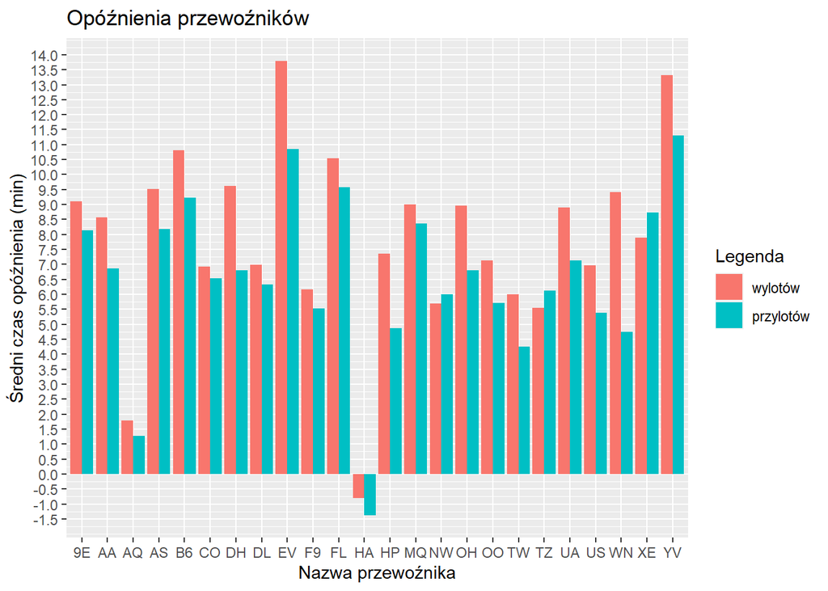

Można zauważyć, że najlepiej wypadają przewoźniki HA (Hawaiian Airlines Inc.) i AQ (Aloha Airlines). Z czego HA ma ujemną srednią opoźnień, co oznacza, że samoloty średnio przybywały i wylatywały za wcześnie. Niskie średnie opóźnień mogą być spowodowane tym, że ci przewoźnicy mieli najmniejszą liczbę lotów. Natomiast najgorzej prezentują się YV (Mesa Airlines) oraz EV (ExpressJet Airlines).

## 2. Procent odwołanych lotów z powodu przewoźnika

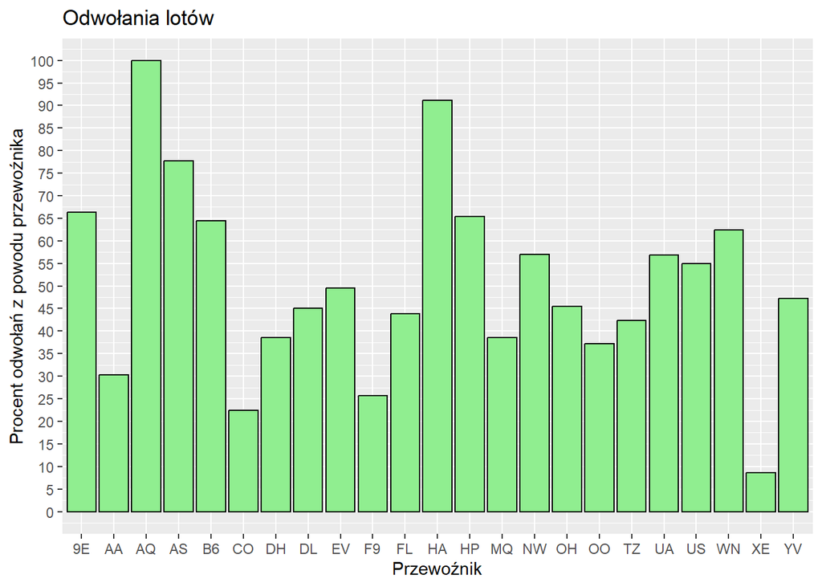

Uwaga: brak danych dla TW (Trans World Airlines), gdyż lnia lotnicza ogłosiła bankructwo w 2001 i brakuje jakichkolwiek lotów po 2001.

Natomiast najgorzej wypadają AQ i HA, gdzie ponad 90% odwołanych lotów było z przyczyny przewoźnika. Warto wziąć jednak pod uwagę, że te linie miały najmniej odwołanych lotów łącznie.

## 3. Liczba zmienionych tras lotów

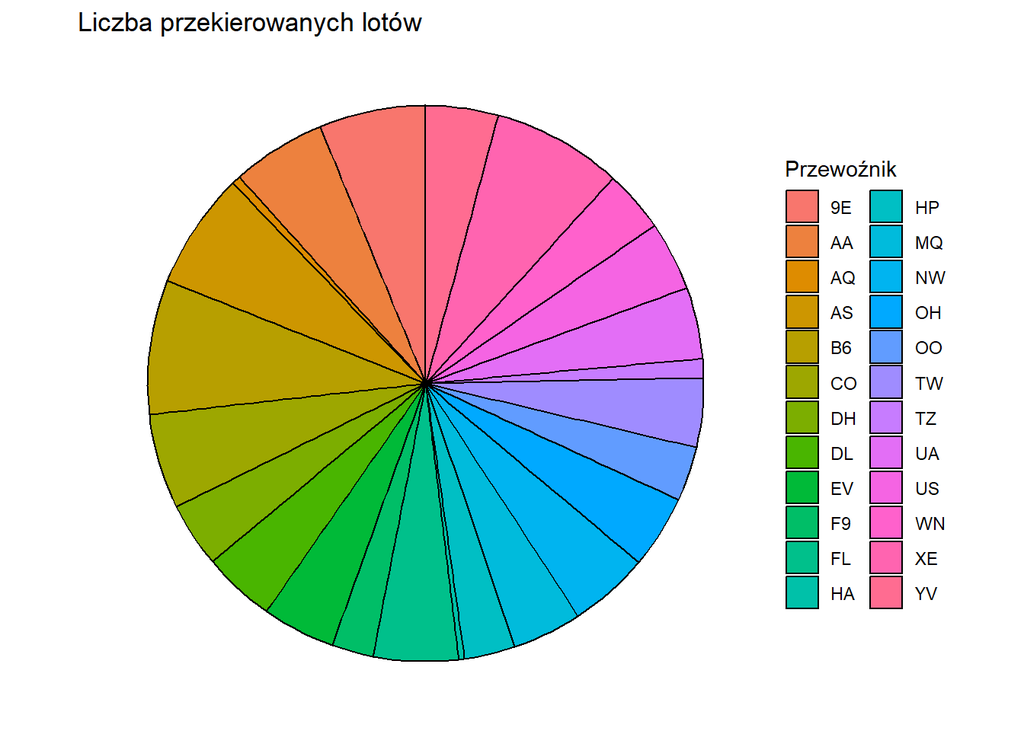

Ponieważ każdy przewoźnik ma różną liczbę lotów, to dane przekierowanych lotów zostały odpowiednio przeskalowane do maksymalnej liczby lotów.

Tutaj ponownie najlepiej wypadają linie HA i AQ, które miały najmniej przekierowanych lotów. Nieco gorzej radzi sobie TZ (ATA Airlines). Natomiast najgorzej prezentuje się sytuacja, jeśli chodzi o linie B6 (Jetblue Airways Corporation) i XE (JetSuiteX). Warto jednak dodać, że przewoźnicy ci znajdują się odpowiednio na 17 i 10 miejscu, jeśli chodzi o największą liczbę lotów, więc liczba lotów niekoniecznie musi wpływać na liczbę przekierowanych lotów.

## 4. Średnie opóźnień z powodu przewoźnika

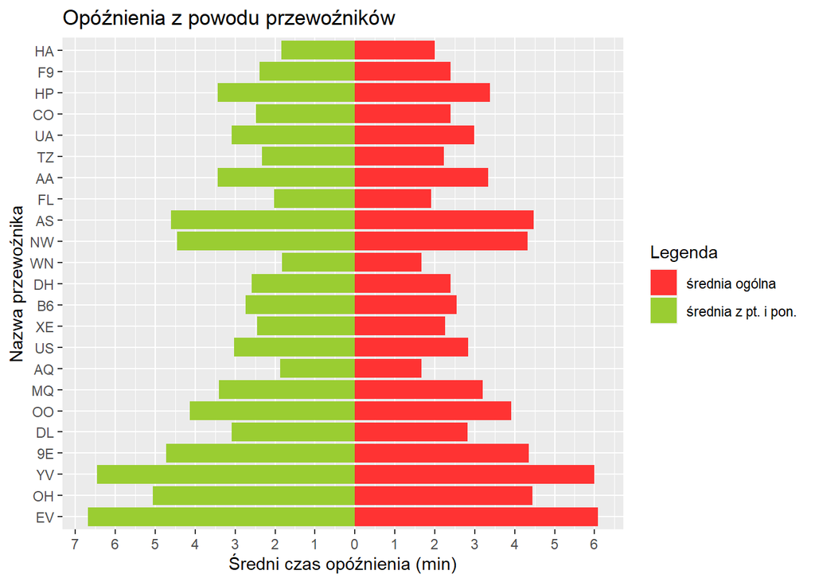

| DayOfWeek | ile |
| --- | --- |
| pon. | 6868782 |
| pt. | 6867742 |
| czw. | 6850879 |
| śr. | 6815210 |
| wt. | 6779060 |
| nd. | 6496628 |
| sob. | 5914381 |

Ponieważ, jak wynika z tabeli, ludzie najchętniej latają w piątek i poniedziałek, więc średnia łączna została zestawiona ze średnią w te dni. W ten sposób można dowiedzieć się, czy przewoźnicy radzą sobie gorzej z większym natężeniem ruchu.

Widzimy tutaj, że średnia z piątku i poniedziałku jest przeważnie nieco wyższa niż ta z całego tygodnia. Stąd odpowiedź jest tak, ale nieznacznie.

Najmniejszy średni czas opóźnienia z powdou przewoźnika ma WN (Southwest Airlines) w obu kategoriach. Patrząc na średnią ogólną to kolejnymi przewoźnikami są AQ, FL (AirTran Airways) i HA. Jednak porównując po średniej tylko z piątku i poniedziałku kolejność wygląda następująco: HA, AQ, FL. Natomiast największe opóźnienia mają przewoźniki EV (ExpressJet Airlines) i YV (Mesa Airlines) kolejno, zarówno ogólnie jak i w te dwa dni.

## Podsumowanie:

Z powyższych rozważań wynika, że najlepiej prezentują się linie AQ (Aloha Airlines) oraz HA (Hawaiian Airlines Inc.). Jednak warto wziąć pod uwagę, że ci przewoźnicy mają niewielką liczbę lotów w porównaniu z innymi (1 i 3 miejsca od końca odpowiednio) oraz jeśli samoloty tych lini są odwoływane to najczęściej jest to wina tych oto przewoźników.

**Nastepujace wykresy sa wykonane w shiny, jednak niestety, ‘demonstracja’ dopiero bedzie mozliwa w trakcie trwania prezentacji**

## **1) Najszybsze samoloty w latach 2001-2007**

> Sprawdzamy po sredniej predkosci dla kazdego samolotu

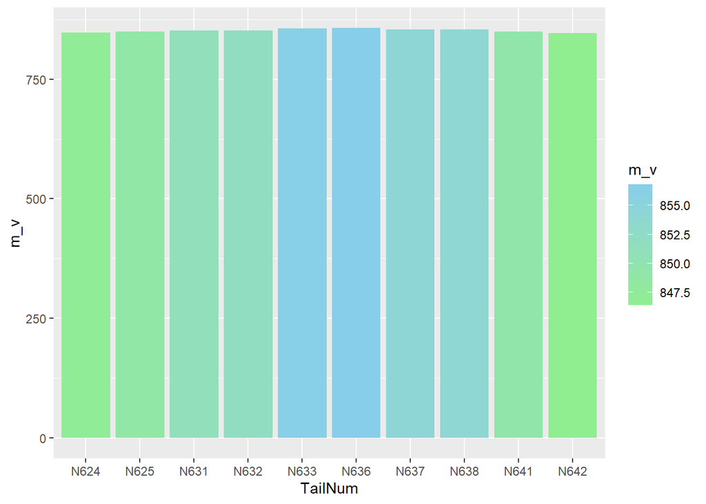

## **Tabela ze skrotami przewoznikow**

[output not shown]

## **2) Liczba lotow dla kazdego przewoznika w poszczegolnych latach 2001-2007**

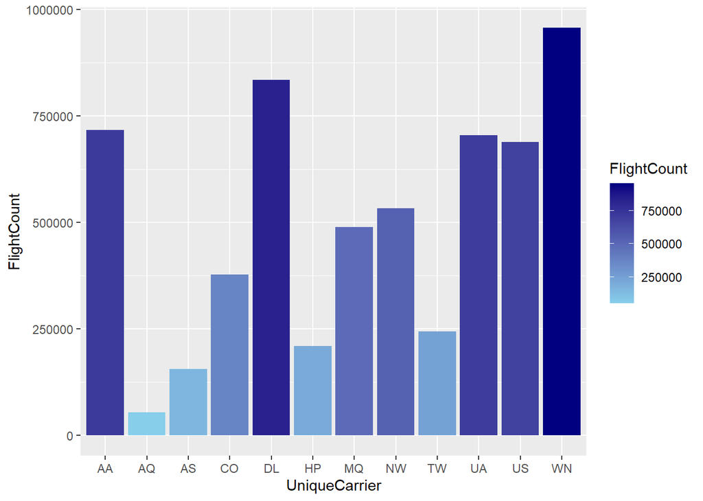

## **3) Punktualnosc przewoznikow w latach 2001-2007 (w shiny)**

> Dla kazdego z przewoznikow mamy dokladna analize tego jak punktualni byli w poszczegolnych latach oraz miesiacach

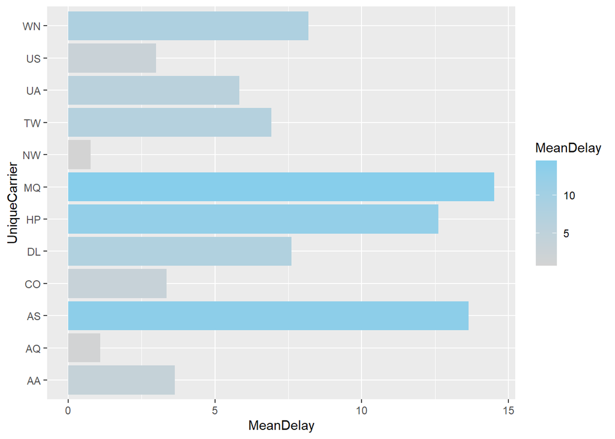

## **4) Jakich polaczen bylo najwiecej w latach 2001-2007 (w shiny)?**

> Przedstawione dane dotycza najczestszych polaczen miedzy lotniskami w USA w styczniu 2001r.

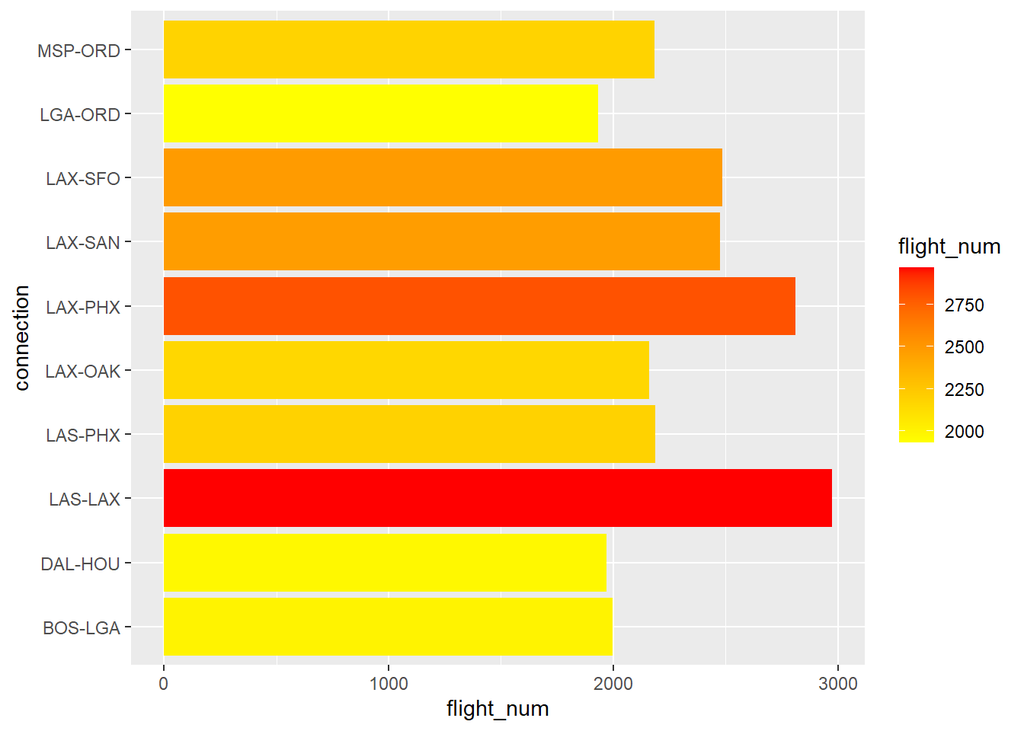

## **5)Nowym Jorku - Lotniska 2001-2007 (w shiny)**

> W przedstawionym zestawieniu mamy ilosc lotow (krajowych) w latach 2001-2007 oraz w poszczegolnych miesiacach.

| JFK | Lotnisko Kennedy’ego – John F. Kennedy International Airport |
| --- | --- |
| EWR | Port Lotniczy Newark-Liberty |
| LGA | Lotnisko La Guardia |

**Ciekawostka:** JFK jest najwiekszym lotniskiem w Nowym Jorku, jednak lotow krajowych ma najmniej w Nowym Jorku

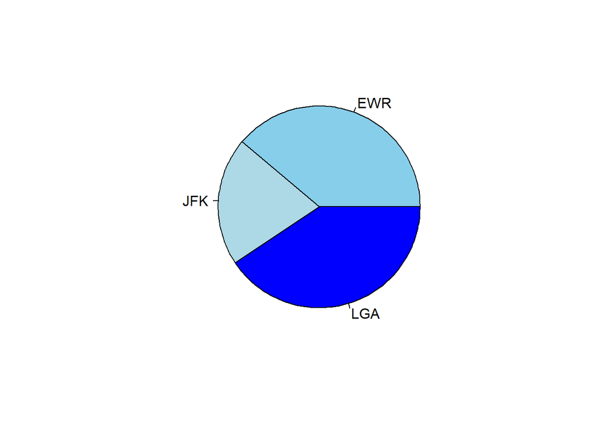

## **6) Natezenie ruchu lotniczego w latach 2001-2007 (w shiny)**

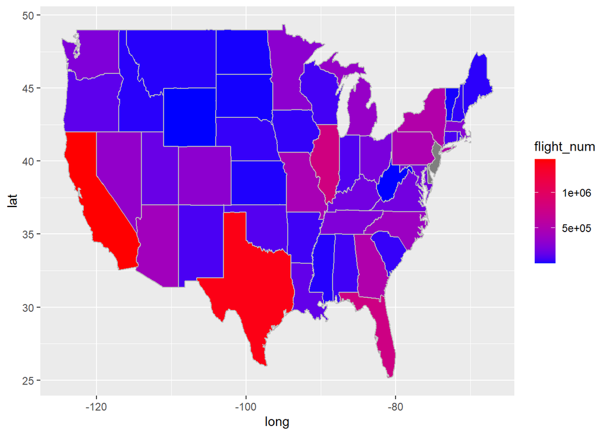

## Źródła:

https://aspm.faa.gov/aspmhelp/index/ASQP__Carrier_Codes_and_Names.html  
https://en.wikipedia.org/wiki/Trans_World_Airlines  
https://dataverse.harvard.edu/dataset.xhtml?persistentId=doi:10.7910/DVN/HG7NV7  
https://ourairports.com/data/